# California Wildfires Report

Abigail Chutnik, Ben Lewis, Hangliang Ren, Alex Andrei Ungureanasu

11/20/2021

## Introduction

The western United States has faced increasing amounts of wildfires in the last decade. Wildfires are a major threat to the population’s own health and the health of our environment. Currently, many speculate that the increasing amounts of wildfires may be due to climate change and it’s associated increasing temperatures. To understand more about wildfires in the West coast, our report investigates the trends in wildfires, specifically in California.

## Summary

In order to analyze the trends within the last decade, our analysis focuses on the years 2013 to 2020. Wildfires show tremendous consequences on our environment as each year, **1,070,651** acres of land were impacted by wildfires. Specifically, **Riverside** county suffered from wildfires the most during this time period. Additionally, **2017** was the worst year for wildfires in California, since the most occurred during that year. We also wanted to look at the proportion of equipment used by firefighters and personnel, and found that engines are used the most. The proportions of these equipment used are Airtankers, Dozers, and Engines and their proportions are, respectively, **0.0171149**, **0.0751834**, and **0.1167482**. Lastly, we were curious about the average labor participated in handling the wildfires, which were about **580** in 2013 and decreased to **227** in 2017, with the average change of **60%**.

## Table

This table is included to showcase the trends in wildfire deaths over the years. In this table, we noticed an increase in wildfire related deaths from 2017 to 2018, and a sudden decrease in 2019.

```
##    Year CA Wildfire Deaths
## 1: 2013                  0
## 2: 2014                  0
## 3: 2015                  1
## 4: 2016                  0
## 5: 2017                 75
## 6: 2018                102
## 7: 2019                  3
```

We feel that it is very important to show a table displaying the trend of deaths caused by wildfires. It gives our users a very direct impression about how destructive & harmful wildfire is. Also, sorted by time, our users can clearly identify the how huge the wildfire influence is in each year, and how it is changed over years. This can inpsire our users to do some further look / research about wildfires in those years caused most serious influence.

## Chart 1

This bar graph includes the number of acres burned per year in order to showcase the amount of damage done by wildfires over time. It shows the number of burned acres from 2013 to 2019. This can help our users identify during which years among 2013-2019, California suffered the most influence from wildfires.

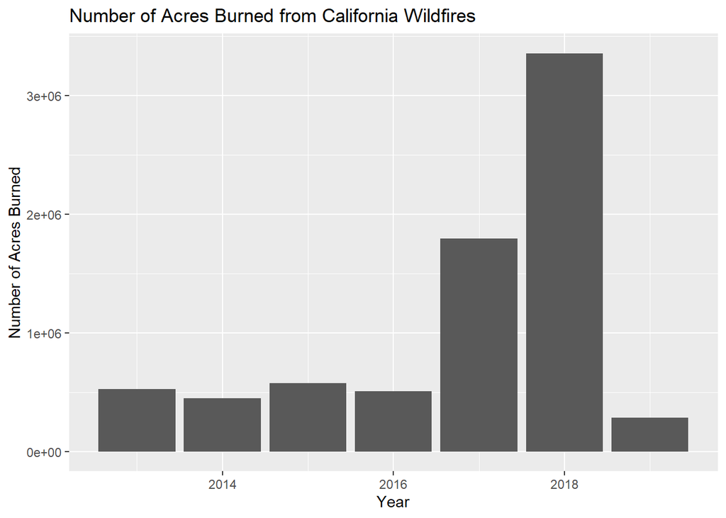

From the chart, we can see that the number of acres burned hugely increased during 2017 & 2018, and drop sharply in 2019. This means that some huge wildfires occurred in 2017-2018, and went back to normal in 2019.

## Chart 2

This line graph demonstrates the frequencies of equipment and machinery used by firefighters and personnel to handle wildfires over time. It demonstrates trends of using Dozers, Engines, and Helicopters from 2013 to 2019. This trends is helpful to help our users identify which equipments are used most frequently and how equipments usage is changed over years. Trends for these types of equipment are quite similar, besides the magnitude of each as shown with the high amount of “Engines” being used.

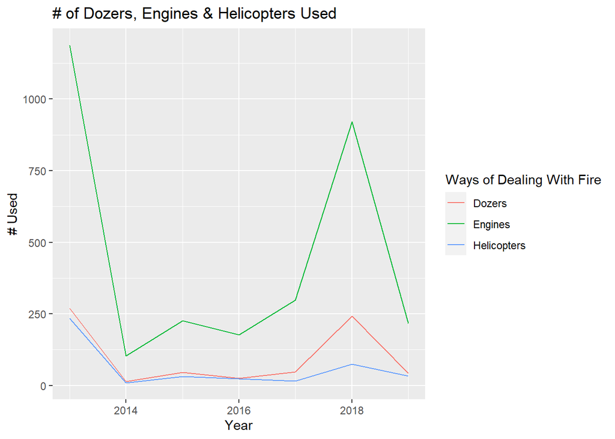

## Chart 3

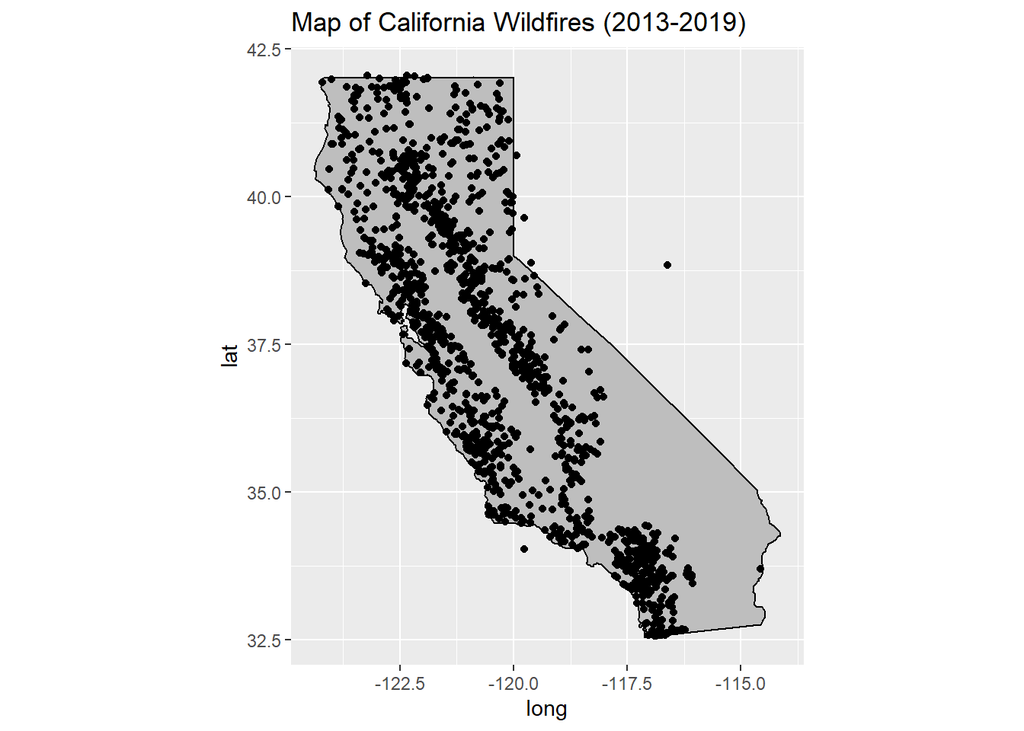